# Calculate background 21Ne from U and Th concentrations in quartz

Read original data csv from Dan Morgan

|  | sample_id | wtkg | Al | Ba | Be | Ca | Cr | Cu | Fe | K | Li | Mg | Mn | Ni | P | Sc | Sr | Ti | V | Zn | Si | Ag | As | Bi | Cd | Ce | Co | Cs | Dy | … |
| --- | --- | --- | --- | --- | --- | --- | --- | --- | --- | --- | --- | --- | --- | --- | --- | --- | --- | --- | --- | --- | --- | --- | --- | --- | --- | --- | --- | --- | --- | --- |
| 1 | METHOD | G_WGH79 | GE_ICM90A | GE_ICM90A | GE_ICM90A | GE_ICM90A | GE_ICM90A | GE_ICM90A | GE_ICM90A | GE_ICM90A | GE_ICM90A | GE_ICM90A | GE_ICM90A | GE_ICM90A | GE_ICM90A | GE_ICM90A | GE_ICM90A | GE_ICM90A | GE_ICM90A | GE_ICM90A | GE_ICM90A | GE_ICM90A | GE_ICM90A | GE_ICM90A | GE_ICM90A | GE_ICM90A | GE_ICM90A | GE_ICM90A | GE_ICM90A | … |
| 2 | DETECTION | 0.001 | 0.01 | 10 | 5 | 0.1 | 10 | 10 | 0.01 | 0.1 | 10 | 0.01 | 10 | 5 | 0.01 | 5 | 10 | 0.01 | 5 | 5 | 0.1 | 1 | 5 | 0.1 | 0.2 | 0.1 | 0.5 | 0.1 | 0.05 | … |
| 3 | UNITS | kg | % | ppm | ppm | % | ppm | ppm | % | % | ppm | % | ppm | ppm | % | ppm | ppm | % | ppm | ppm | % | ppm | ppm | ppm | ppm | ppm | ppm | ppm | ppm | … |
| 4 | 10-OV-Pit 1 13-16cm | 0.01 | 0.09 | &lt;10 | &lt;5 | &lt;0.1 | 252 | &lt;10 | 0.25 | &lt;0.1 | &lt;10 | &lt;0.01 | 23 | 10 | &lt;0.01 | &lt;5 | &lt;10 | &lt;0.01 | &lt;5 | 6 | &gt;30 | &lt;1 | &lt;5 | &lt;0.1 | &lt;0.2 | 2.3 | &lt;0.5 | 0.1 | 0.13 | … |
| 5 | 10-OV-Pit 5 Peb | 0.014 | 0.01 | &lt;10 | &lt;5 | &lt;0.1 | 224 | &lt;10 | 0.22 | &lt;0.1 | &lt;10 | &lt;0.01 | 23 | 9 | &lt;0.01 | &lt;5 | &lt;10 | &lt;0.01 | &lt;5 | 6 | &gt;30 | &lt;1 | &lt;5 | &lt;0.1 | &lt;0.2 | 0.6 | &lt;0.5 | &lt;0.1 | &lt;0.05 | … |
| 6 | 10-OV-Pit 5 41-45cm | 0.011 | 0.02 | &lt;10 | &lt;5 | &lt;0.1 | 261 | &lt;10 | 0.24 | &lt;0.1 | &lt;10 | &lt;0.01 | 22 | 10 | &lt;0.01 | &lt;5 | &lt;10 | &lt;0.01 | &lt;5 | &lt;5 | &gt;30 | &lt;1 | &lt;5 | &lt;0.1 | &lt;0.2 | 0.9 | 0.5 | &lt;0.1 | 0.08 | … |
| 7 | 10-OV-Pit 12 32-36cm | 0.009 | &lt;0.01 | &lt;10 | &lt;5 | &lt;0.1 | 415 | &lt;10 | 0.37 | &lt;0.1 | &lt;10 | &lt;0.01 | 31 | 11 | &lt;0.01 | &lt;5 | &lt;10 | &lt;0.01 | &lt;5 | 5 | &gt;30 | &lt;1 | &lt;5 | &lt;0.1 | &lt;0.2 | 0.6 | 0.6 | &lt;0.1 | &lt;0.05 | … |
| 8 | 10-OV--BR-01 | 0.008 | &lt;0.01 | &lt;10 | &lt;5 | &lt;0.1 | 332 | &lt;10 | 0.3 | &lt;0.1 | &lt;10 | &lt;0.01 | 27 | 12 | &lt;0.01 | &lt;5 | &lt;10 | &lt;0.01 | &lt;5 | &lt;5 | &gt;30 | &lt;1 | &lt;5 | &lt;0.1 | &lt;0.2 | 0.6 | 0.6 | &lt;0.1 | &lt;0.05 | … |
| 9 | 10-OV--BR-03 | 0.011 | &lt;0.01 | &lt;10 | &lt;5 | &lt;0.1 | 287 | &lt;10 | 0.26 | &lt;0.1 | &lt;10 | &lt;0.01 | 25 | 10 | &lt;0.01 | &lt;5 | &lt;10 | &lt;0.01 | &lt;5 | 6 | &gt;30 | &lt;1 | &lt;5 | &lt;0.1 | &lt;0.2 | 0.2 | &lt;0.5 | &lt;0.1 | &lt;0.05 | … |
| 10 | 10-OV--BR-09 | 0.013 | 0.01 | &lt;10 | &lt;5 | &lt;0.1 | 233 | &lt;10 | 0.22 | &lt;0.1 | &lt;10 | &lt;0.01 | 20 | 8 | &lt;0.01 | &lt;5 | &lt;10 | &lt;0.01 | &lt;5 | &lt;5 | &gt;30 | &lt;1 | &lt;5 | &lt;0.1 | &lt;0.2 | 13.4 | &lt;0.5 | 0.1 | 0.28 | … |

[output cut: 21 more lines]

We need to remove special characters from data and adjust headers so every row is an observation and every column is a category

|  | sample_id | wtkg | element | ppm | numeric_ppm | below_limit_ppm |
| --- | --- | --- | --- | --- | --- | --- |
| 1 | 10-MC-BR-18 | 0.011 | Al | 0.03 | 0.03 | False |
| 2 | 10-MC-BR-18 | 0.011 | Ba | &lt;10 |  | True |
| 3 | 10-MC-BR-18 | 0.011 | Be | &lt;5 |  | True |
| 4 | 10-MC-BR-18 | 0.011 | Ca | &lt;0.1 |  | True |
| 5 | 10-MC-BR-18 | 0.011 | Cr | 292 | 292 | False |
| 6 | 10-MC-BR-18 | 0.011 | Cu | &lt;10 |  | True |
| 7 | 10-MC-BR-18 | 0.011 | Fe | 0.27 | 0.27 | False |
| 8 | 10-MC-BR-18 | 0.011 | K | &lt;0.1 |  | True |
| 9 | 10-MC-BR-18 | 0.011 | Li | &lt;10 |  | True |
| 10 | 10-MC-BR-18 | 0.011 | Mg | &lt;0.01 |  | True |

[output cut: 1558 more lines]

Constants: These need to be double checked and confirmed with citeable online source.

|  | element | isotope | abundance | mass | num_alpha_decays_in_chain | ne21_nucleogenic_P_rate | lambda |
| --- | --- | --- | --- | --- | --- | --- | --- |
| 1 | U | U238 | 0.992742 | 238.050788247 | 8 | 4.04e-08 | 1.55135895380471e-10 |
| 2 | U | U235 | 0.007204 | 235.043929918 | 7 | 5.62e-08 | 9.84863854163037e-10 |
| 3 | Th | Th232 | 1 | 232.038055325 | 6 | 6.08e-08 | 4.93343189010637e-11 |

Separate U and Th into their respective isotopes: Coxx et al provides neon prodution rates as a function of U235, U238, and Th232. This means we need to normalize the measured ppm of U and Th to their respective abundances before proceeding. As an example, if our measured total U concentraion is 100 ppm, and the abundance of U235 is 1% and U238 is 99%, we expect that in our sample, of 100ppm, 1ppm is U235 and the remaining 99ppm is U238. These get summed at the end to calculate toal Ne21.

|  | sample_id | element | isotope | isoprop | numeric_ppm | iso_ppm |
| --- | --- | --- | --- | --- | --- | --- |
| 1 | 10-MC-BR-18 | Th | Th232 | 1 | 1 | 1 |
| 2 | 10-MC-BR-18 | U | U238 | 0.992742 | 0.17 | 0.16876614 |
| 3 | 10-MC-BR-18 | U | U235 | 0.007204 | 0.17 | 0.00122468 |
| 4 | 10-MC-BR-19 | Th | Th232 | 1 | 0.9 | 0.9 |
| 5 | 10-MC-BR-19 | U | U238 | 0.992742 | 0.16 | 0.15883872 |
| 6 | 10-MC-BR-19 | U | U235 | 0.007204 | 0.16 | 0.00115264 |
| 7 | 10-MC-ERR-20 | Th | Th232 | 1 | 0.2 | 0.2 |
| 8 | 10-MC-ERR-20 | U | U238 | 0.992742 | 0.08 | 0.07941936 |
| 9 | 10-MC-ERR-20 | U | U235 | 0.007204 | 0.08 | 0.00057632 |
| 10 | 10-MC-ERR-22 | Th | Th232 | 1 | 0.2 | 0.2 |

[output cut: 74 more lines]

For simplicty and math sake we merge our data and constants into a single dataframe.

|  | sample_id | wtkg | element.x | ppm | numeric_ppm | below_limit_ppm | isotope | iso_ppm | isoprop | element.y | abundance | mass | num_alpha_decays_in_chain | ne21_nucleogenic_P_rate | lambda | avogadro | sampleAge |
| --- | --- | --- | --- | --- | --- | --- | --- | --- | --- | --- | --- | --- | --- | --- | --- | --- | --- |
| 1 | 10-MC-BR-18 | 0.011 | Al | 0.03 | 0.03 | False |  | 0.03 | 1 |  |  |  |  |  |  | 6.022e+23 | 100000000 |
| 2 | 10-MC-BR-18 | 0.011 | Ba | &lt;10 |  | True |  |  | 1 |  |  |  |  |  |  | 6.022e+23 | 100000000 |
| 3 | 10-MC-BR-18 | 0.011 | Be | &lt;5 |  | True |  |  | 1 |  |  |  |  |  |  | 6.022e+23 | 100000000 |
| 4 | 10-MC-BR-18 | 0.011 | Ca | &lt;0.1 |  | True |  |  | 1 |  |  |  |  |  |  | 6.022e+23 | 100000000 |
| 5 | 10-MC-BR-18 | 0.011 | Cr | 292 | 292 | False |  | 292 | 1 |  |  |  |  |  |  | 6.022e+23 | 100000000 |
| 6 | 10-MC-BR-18 | 0.011 | Cu | &lt;10 |  | True |  |  | 1 |  |  |  |  |  |  | 6.022e+23 | 100000000 |
| 7 | 10-MC-BR-18 | 0.011 | Fe | 0.27 | 0.27 | False |  | 0.27 | 1 |  |  |  |  |  |  | 6.022e+23 | 100000000 |
| 8 | 10-MC-BR-18 | 0.011 | K | &lt;0.1 |  | True |  |  | 1 |  |  |  |  |  |  | 6.022e+23 | 100000000 |
| 9 | 10-MC-BR-18 | 0.011 | Li | &lt;10 |  | True |  |  | 1 |  |  |  |  |  |  | 6.022e+23 | 100000000 |
| 10 | 10-MC-BR-18 | 0.011 | Mg | &lt;0.01 |  | True |  |  | 1 |  |  |  |  |  |  | 6.022e+23 | 100000000 |

[output cut: 1586 more lines]

## Now we’re ready to do some calculations

#### Parent Atoms

Calculate the number of original parent atoms of U and Th based on the measured concentration of each element.

Formula: parent_atoms = (numeric_ppm/1E6)*wtkg*1000*abundance*(1/mass)*avogadro)

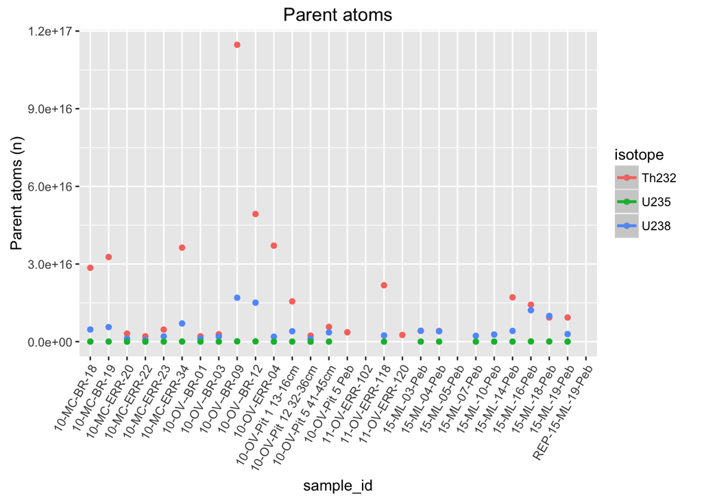

#### Alpha decays

How many radioactive alpha decays have occurred during the lifetime of the sample? This is based on the age of the sample, the original concentration of parent isotopes, and the 1/2 life of the isotope.

Formula: alpha_decays = parent_atoms*(exp(lambda*sampleAge)-1)

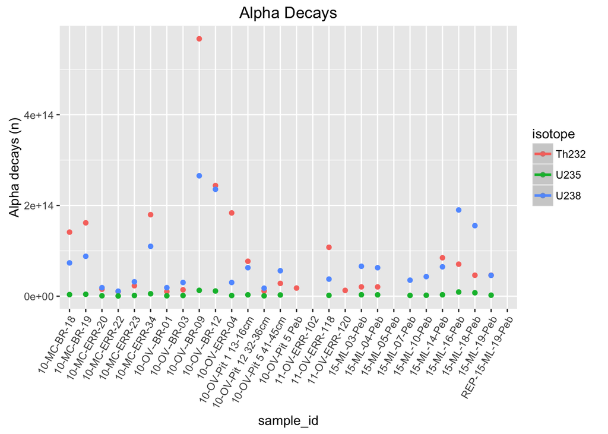

#### Alpha particles

Since we know how many radioactive alpha decays have occured from the parent atom of each sample, we can calculate the number of alpha particles that have been emitted in the crystal lattice for the lifetime of the sample.This is important because it’s the emission of an alpha particle which then interacts with an oxygen isotope in quartz to form 21Ne. The number of ejected alpha particles is based on the number of alpha decays that occur in the parent isotope during the decay process. If you look at the Thorium series decay chain (or decay path), you’ll see that there are 6 alpha particles emited.[https://en.wikipedia.org/wiki/Decay_chain] Thus, we are just multiplying the number of radioactive decays that have occurred times the number of alpha particles emitted for each radioactive decay to get the total number of alpha particles that can smash into oxygen isotopes to form 21Ne.

Formula:alpha_particles = num_alpha_decays_in_chain*alpha_decays

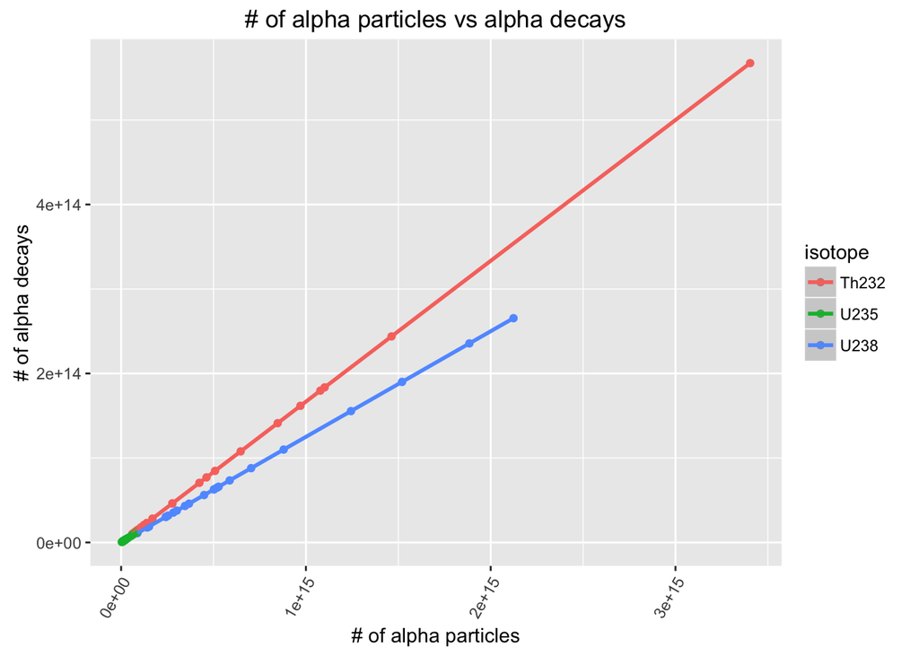

#### Neon 21 from normal radioactive decay

So how much 21Ne is produced in-situ from normal radioactive decay of nearby U and Th? We are now relying on the total number of alpha particles we just calculated and the experimental results of Coxx et al for the production rate of Neon in quartz. Coxx et al blasted some pure quartz standards with an ion source and in their paper provide production rates in Table 6. So again we just need to multiply the number of total alpha particles ejected from U and Th by the “alpha based production rate or nucleogenic production rate” of 21Ne (atoms/alpha particle).

Formula: ne21_nucl_n_atoms = alpha_particles*ne21_nucleogenic_P_rate

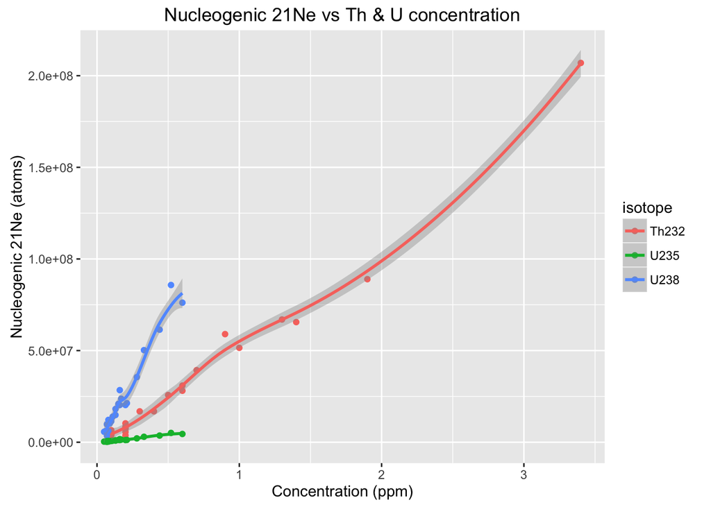

Above: What are we learning here? As expected, the greater the concentration of U and Th, the greater the concentration of 21Ne. In the U series, U238 is the dominant producer of 21Ne but it is also 99% abundant (as compared to U235). There’s something else here, but I can’t put my finger on it. I go into it below.

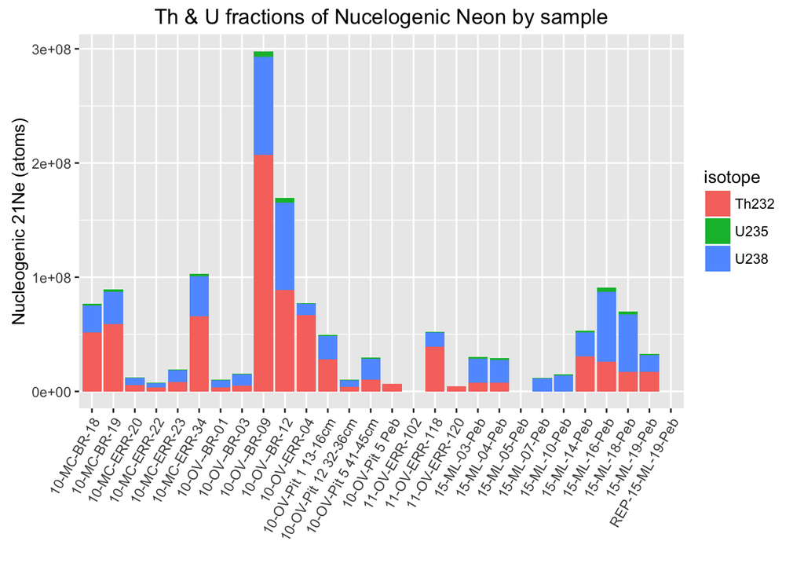

We can compare this relationship of ppm to concentration using the previous plot. Maybe it’s a slope issue? U has a steeper slope so at lower concentrations (ppm) it produces more neon than Th?

Lets do the same plot as above but highlight a few choice samples

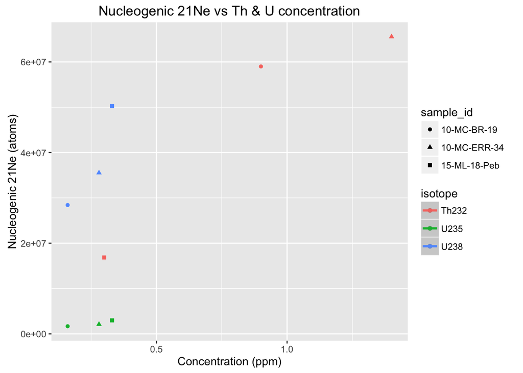

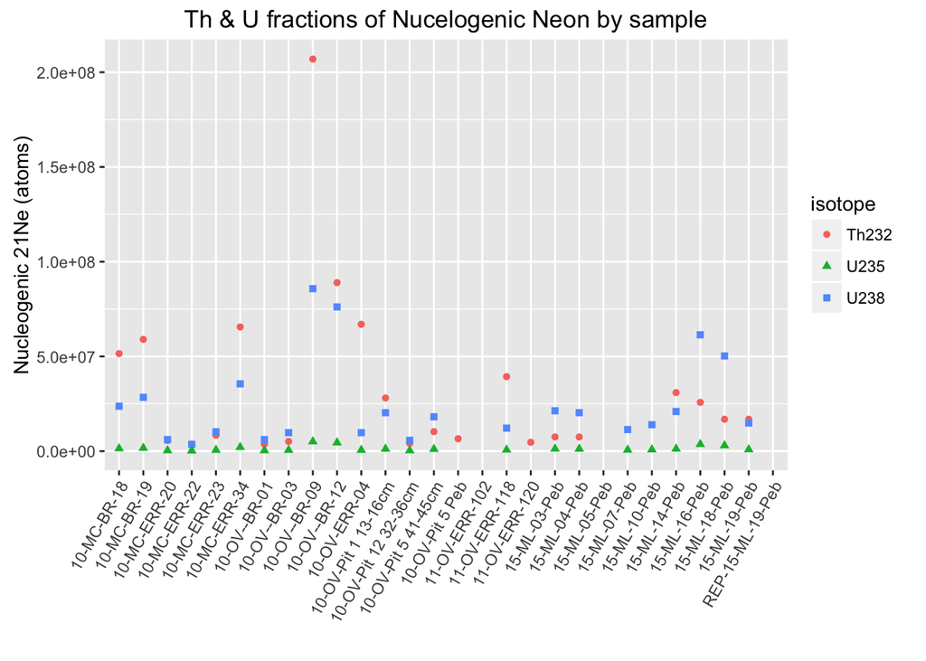

Same thing as above just dots

## Import measured 21Ne concentrations from BGC

File named: Morgan_MonoBasin_Pebbles_Ne21_clean.csv

|  | filename | sample.name | aliquot | quartz.weight..g. | heating.temp..deg.c. | heating.time..hr. | total.ne.20.released..gatoms. | error | total.ne.21.released..matoms. | error.1 | total.ne.22.released..matoms. | error.2 | ne.21.ne.20..10..3. | error.3 | ne.22.ne.20..10..3. | error.4 | cosmogenic.ne.21.each.aliquot.best.normalization..matoms.g. | error.5 | cosmogenic.pct.of.total.ne.21.this.aqt | this.aqt.pct.of.total.ne.21 | total.cosmogenic.ne.21...matoms.g. | error.6 | trapped.ne.21...matoms.g. | total.ne.21...matoms. | error.7 | matoms.g |
| --- | --- | --- | --- | --- | --- | --- | --- | --- | --- | --- | --- | --- | --- | --- | --- | --- | --- | --- | --- | --- | --- | --- | --- | --- | --- | --- |
| 1 | OhioNe5639.dat | 15-ML-11-PEB | a | 0.1468 | 400 | 0.25 | 0.7227 | 0.0168 | 2.687 | 0.137 | 74.353 | 2.103 | 3.739 | 0.175 | 101.1 | 2.5 | 3.85 | 0.85 | 21.03386677 | 43.94977169 | 8.76 | 1.205197079 | 27.39122616 | 5.307 | 0.188515251 | 36.15122616 |
| 2 | OhioNe5650.dat | 15-ML-11-PEB | a | 0.1468 | 850 | 0.25 | 0.5715 | 0.0132 | 2.253 | 0.112 | 61.515 | 2.034 | 3.939 | 0.187 | 106.2 | 3.2 | 3.82 | 0.72 | 24.89019086 | 43.60730594 | 8.76 | 1.205197079 | 27.39122616 | 5.307 | 0.188515251 | 36.15122616 |
| 3 | OhioNe5661.dat | 15-ML-11-PEB | a | 0.1468 | 1100 | 0.2 | 0.07 | 0.0074 | 0.367 | 0.065 | 7.533 | 1.385 | 5.242 | 1.07 | 106 | 22.3 | 1.09 | 0.46 | 43.6 | 12.44292237 | 8.76 | 1.205197079 | 27.39122616 | 5.307 | 0.188515251 | 36.15122616 |
| 4 |  |  |  |  |  |  |  |  |  |  |  |  |  |  |  |  |  |  |  |  |  |  |  |  |  |  |
| 5 | OhioNe5640.dat | 15-ML-12-PEB | a | 0.1453 | 400 | 0.25 | 0.6159 | 0.0149 | 2.416 | 0.11 | 61.078 | 1.905 | 3.946 | 0.163 | 97.4 | 2.8 | 4.19 | 0.68 | 25.19896523 | 37.74774775 | 11.1 | 1.102950588 | 24.32326222 | 5.147 | 0.169776323 | 35.42326222 |
| 6 | OhioNe5651.dat | 15-ML-12-PEB | a | 0.1453 | 850 | 0.25 | 0.5304 | 0.013 | 2.42 | 0.11 | 52.071 | 1.844 | 4.556 | 0.2 | 96.8 | 3.2 | 5.85 | 0.71 | 35.12417355 | 52.7027027 | 11.1 | 1.102950588 | 24.32326222 | 5.147 | 0.169776323 | 35.42326222 |
| 7 | OhioNe5663.dat | 15-ML-12-PEB | a | 0.1453 | 1100 | 0.2 | 0.0532 | 0.0084 | 0.311 | 0.068 | 6.646 | 1.311 | 5.853 | 1.569 | 122.8 | 30.9 | 1.06 | 0.5 | 49.52347267 | 9.54954955 | 11.1 | 1.102950588 | 24.32326222 | 5.147 | 0.169776323 | 35.42326222 |
| 8 |  |  |  |  |  |  |  |  |  |  |  |  |  |  |  |  |  |  |  |  |  |  |  |  |  |  |
| 9 | OhioNe5641.dat | 15-ML-13-PEB | a | 0.1431 | 400 | 0.25 | 0.5589 | 0.0132 | 2.494 | 0.118 | 58.055 | 1.747 | 4.486 | 0.193 | 102 | 2.7 | 5.98 | 0.74 | 34.31186848 | 48.07073955 | 12.44 | 1.3897122 | 31.89263452 | 6.344 | 0.21196462 | 44.33263452 |
| 10 | OhioNe5652.dat | 15-ML-13-PEB | a | 0.1431 | 850 | 0.25 | 0.8585 | 0.0191 | 3.381 | 0.162 | 87.455 | 2.546 | 3.933 | 0.178 | 100.5 | 2.5 | 5.86 | 1.06 | 24.80230701 | 47.10610932 | 12.44 | 1.3897122 | 31.89263452 | 6.344 | 0.21196462 | 44.33263452 |

[output cut: 52 more lines]

##